# DATA608 Final Project

LeTicia Cancel

5/20/2022

```r
library(dplyr)
library(ggplot2)
library(shiny)
library(plotly)
library(stringr)
require(maps)
require(gridExtra)
library(tidyr)
library(rmarkdown)
library(knitr)
library(kableExtra)
```

# Food Insecurity in America

Food insecurity as defined by the U.S. Department of Agriculture is the “household-level economic and social condition of limited or uncertain access to adequate food”. [1](https://www.ers.usda.gov/topics/food-nutrition-assistance/food-security-in-the-u-s/definitions-of-food-security/) We will explore the distribution of individuals and families who use programs to assist with food. We will also explore responses from a survey conducted by the U.S. Census Bureau that asks participants how they viewed their current food security.

# Datasets

```r
#load data from github
snap_person <- read.csv("https://raw.githubusercontent.com/ltcancel/DATA608/main/Final%20Project/SNAP%20Person%20Count%2005032022_cleaned.csv")
snap_hh <- read.csv("https://raw.githubusercontent.com/ltcancel/DATA608/main/Final%20Project/SNAP%20Household%20Count%2005032022_cleaned.csv")
survey_df <- read.csv("https://raw.githubusercontent.com/ltcancel/DATA608/main/Final%20Project/Food%20Security%20Survey.csv")
```

Three datasets were used for this analysis. The first is a count of individuals participating in Supplemental Nutrition Assistance Program (SNAP) in February 2022. The data is as of May 3, 2022. [2](https://www.fns.usda.gov/pd/supplemental-nutrition-assistance-program-snap) The original data compares the number of individuals participating in SNAP in February 2021, January 2022, February 2022, and the percentage change from last year to this year. For the purpose of this project, we will only use the most recent count, February 2022 data for each state.

```r
#preview SNAP Persons dataframe
kable(head(snap_person)) %>%
  kable_styling(position = "center")
```

| State | February |
| --- | --- |
| Alabama | 750,939 |
| Alaska | 95,170 |
| American Samoa | – |
| Arizona | 799,080 |
| Arkansas | 304,315 |
| California | 4,489,949 |

The second dataset compares the number of households participating in SNAP and the data is also as of May 3, 2022. The structure of this dataset is exactly the same as the Persons dataset and we will also only use the most recent count, February 2022 data for each state.

```r
#preview SNAP household dataframe
kable(head(snap_hh)) %>%
  kable_styling(position = "center")
```

| State | February |
| --- | --- |
| Alabama | 372,345 |
| Alaska | 43,839 |
| American Samoa | – |
| Arizona | 375,600 |
| Arkansas | 151,359 |
| California | 2,546,125 |

1. Enough of the kinds of food wanted
2. Enough food, but not always the kinds wanted
3. Sometimes not enough to eat
4. Often not enough to eat
5. Did not report

```r
#preview survey dataframe
#kable(head(survey_df)) %>%
 # kable_styling(position = "center")
#paged_table(survey_df)
#head(survey_df)
```

# Data Cleaning

The SNAP data was cleaned and merged with a map dataframe that contains longitude and latitude information so it can be plotted on a map. The original data in both the persons and household dataframes use “–” to represent missing data so this was replaced with “NA”. The text in the State columns were changed to lowercase so it can be merged with the map data.

```r
#original data before cleaning
snap_hh_original <- snap_hh
snap_person_original <- snap_person
survey_df_original <- survey_df

# clean the February column of both dataframes toreplace '--' with NA and convert to an integer
snap_hh$February <- as.integer(gsub(",","",snap_hh$February))
snap_person$February <- as.integer(gsub(",","",snap_person$February))

# set state field to lowercase so it can be joined with the map data
snap_hh$State <- tolower(snap_hh$State)
snap_person$State <- tolower(snap_person$State)
survey_df <- select(survey_df, -c(US1, US2, US3, US4, US5))

#combine map data from the Maps library which includes longitude and latitude data
states_map <- map_data("state")
snap_hh_map <- merge(snap_hh, states_map, by.x = c("State"), by.y = c("region"))
snap_person_map <- merge(snap_person, states_map, by.x = c("State"), by.y = c("region"))

kable(list(head(snap_hh_original),head(snap_hh)), caption = "SNAP Household dataframe original vs cleaned") %>%
  kable_styling(position = "center")
```

SNAP Household dataframe original vs cleaned

| State | February |
| --- | --- |
| Alabama | 372,345 |
| Alaska | 43,839 |
| American Samoa | – |
| Arizona | 375,600 |
| Arkansas | 151,359 |
| California | 2,546,125 |

| State | February |
| --- | --- |
| alabama | 372345 |
| alaska | 43839 |
| american samoa | NA |
| arizona | 375600 |
| arkansas | 151359 |
| california | 2546125 |

```r
kable(list(head(snap_hh_original),head(snap_hh)), caption = "SNAP Persons dataframe original vs cleaned") %>%
  kable_styling(position = "center")
```

| State | February |
| --- | --- |
| Alabama | 372,345 |
| Alaska | 43,839 |
| American Samoa | – |
| Arizona | 375,600 |
| Arkansas | 151,359 |
| California | 2,546,125 |

| State | February |
| --- | --- |
| alabama | 372345 |
| alaska | 43839 |
| american samoa | NA |
| arizona | 375600 |
| arkansas | 151359 |
| california | 2546125 |

```r
paged_table(survey_df_original)
```

| Question | Characteristics | US1 | US2 | US3 | US4 | US5 | AL1 | AL2 | AL4 | AL4.1 | AL5 | AK1 | AK2 | AK3 | AK4 | AK5 | AZ1 | AZ2 | AZ3 | AZ4 | AZ5 | AR1 | AR2 | AR3 | AR4 | AR5 | CA1 | CA2 | CA3 | … |
| --- | --- | --- | --- | --- | --- | --- | --- | --- | --- | --- | --- | --- | --- | --- | --- | --- | --- | --- | --- | --- | --- | --- | --- | --- | --- | --- | --- | --- | --- | --- |
| Active duty military* | Did not report | 376729 | 185524 | 26957 | 26107 | 1518911 | 2470 | 3770 | NA | NA | 2300 | 1591 | NA | NA | NA | 2496 | 29695 | 2381 | NA | NA | 40721 | 14066 | NA | NA | NA | 5955 | 38096 | 1551 | NA | … |
| Active duty military* | No active duty service (self or spouse) | 132263503 | 53136539 | 17781206 | 5532526 | 38638777 | 1785238 | 933922 | 327689 | 140212 | 573554 | 295024 | 112948 | 27969 | 13282 | 55185 | 3058072 | 1189928 | 448588 | 133905 | 714243 | 1087955 | 555266 | 125965 | 69010 | 379704 | 16100204 | 5914430 | 2269585 | … |
| Active duty military* | Serving in Reserve or National Guard | 329771 | 154861 | 151200 | 17954 | 206286 | 5366 | NA | 2405 | NA | 5025 | 517 | 637 | 376 | NA | 1187 | 1467 | NA | 4747 | NA | NA | NA | 2589 | NA | NA | NA | 53516 | NA | 78973 | … |
| Active duty military* | Serving on active duty | 663222 | 136587 | 108012 | 72232 | 147457 | 15150 | NA | NA | NA | NA | 12551 | 1221 | NA | NA | 1218 | NA | NA | 848 | NA | NA | NA | 1728 | 5865 | NA | NA | 39951 | 38997 | 78973 | … |
| Active duty military* | Spouse serving in Reserve or National Guard | 298609 | 60496 | 106842 | 34262 | 105768 | 15931 | NA | NA | NA | NA | 1147 | NA | NA | NA | NA | NA | 1809 | NA | NA | NA | 6830 | NA | 7173 | 3377 | NA | 18718 | NA | 78973 | … |
| Active duty military* | Spouse serving on active duty | 524758 | 157651 | 115756 | 15419 | 204845 | 7142 | 7142 | NA | NA | 7142 | 1910 | 2319 | NA | 184 | NA | NA | NA | NA | NA | 11478 | NA | 3189 | NA | NA | 2571 | 76395 | 16942 | 78973 | … |
| Age | 18 - 24 | 7702015 | 3139698 | 1228717 | 356425 | 5802623 | 115852 | 24280 | 37101 | NA | NA | 14467 | 5140 | 4895 | 2091 | 12098 | 222554 | 34874 | 40809 | NA | 151228 | 68868 | 8546 | 2844 | NA | 71672 | 1304293 | 639021 | 243786 | … |
| Age | 25 - 39 | 33159593 | 15064539 | 6077600 | 1928029 | 11707257 | 424409 | 261023 | 84616 | 69053 | 179303 | 83395 | 38265 | 9393 | 1981 | 20177 | 645200 | 413495 | 172771 | 62775 | 134249 | 312667 | 159211 | 33291 | 14661 | 103312 | 4154778 | 1854493 | 941594 | … |
| Age | 40 - 54 | 32429927 | 15783564 | 5773226 | 1867733 | 10677385 | 439697 | 303635 | 111822 | 25918 | 199619 | 92175 | 25593 | 7048 | 2612 | 13559 | 844168 | 365829 | 118356 | 8907 | 181288 | 245467 | 134802 | 54976 | 25233 | 115693 | 3856483 | 1592356 | 728041 | … |
| Age | 55 - 64 | 24657176 | 9276297 | 3312001 | 852461 | 6056607 | 351425 | 195698 | 37024 | 16475 | 68671 | 43008 | 29473 | 5999 | 4859 | 6932 | 455769 | 152584 | 87609 | 25581 | 166042 | 222468 | 100681 | 31154 | 17074 | 25005 | 3011931 | 789515 | 262424 | … |

[output cut: 142 more lines]

The Food Security Survey data was also cleaned by transforming a wide dataset to a long dataset. The survey responses and state were in the same column and needed to be split into their own column. The questions were also numbers and needed to be translated to text.

```r
transformed_df <- survey_df %>%
  gather(key = "response", value = "count", AL1:METRO5)

transformed_df$State <- substr(transformed_df$response, 1,2)
transformed_df$response <- substr(transformed_df$response, 3, 3)

transformed_df <- transformed_df %>%
  mutate(response = ifelse(response =="1", "Enough of the kinds of food wanted", ifelse(response=="2", "Enough food, but not always the kinds wanted", ifelse(response=="3", "Sometimes not enough to eat", ifelse(response=="4", "Often not enough to eat", ifelse(response=="5","Did not report",NA))))))

write.csv(transformed_df,"final_df.csv", row.names = FALSE)

kable(head(transformed_df), caption = "Cleaned survey data") %>%
  kable_styling(position = "center")
```

Cleaned survey data

| Question | Characteristics | response | count | State |
| --- | --- | --- | --- | --- |
| Active duty military* | Did not report | Enough of the kinds of food wanted | 2470 | AL |
| Active duty military* | No active duty service (self or spouse) | Enough of the kinds of food wanted | 1785238 | AL |
| Active duty military* | Serving in Reserve or National Guard | Enough of the kinds of food wanted | 5366 | AL |
| Active duty military* | Serving on active duty | Enough of the kinds of food wanted | 15150 | AL |
| Active duty military* | Spouse serving in Reserve or National Guard | Enough of the kinds of food wanted | 15931 | AL |
| Active duty military* | Spouse serving on active duty | Enough of the kinds of food wanted | 7142 | AL |

# Visualizations

Below is a side-by-side comparison of a map and barchart that displays the number of households participating in SNAP. The darker shade represents the lower end of the scale and gets lighter as the scale increments. It is very obvious to see that California has the highest number of households participating in SNAP because of the clear yellow color. New York State is the second highest based on color, followed by Texas and Florida that has what appears to be identical colors. The colors in middle America are a similar darker shade which tell us that these states have the fewest households participating in SNAP. I can think of two possible reasons for the extreme variance in colors between the states mentioned. States with large urban areas such as New York, California, Texas, and Florida have a denser population in their cities when compared to a states in the middle. It is also possible that programs like SNAP may not be available in suburban states.The barchart to the right help confirm the color difference in the map. The bar for California is more than double the length than most states other than New York, Texas, and Florida. The bars for Texas and Florida are nearly the same length but Texas is slightly ahead.

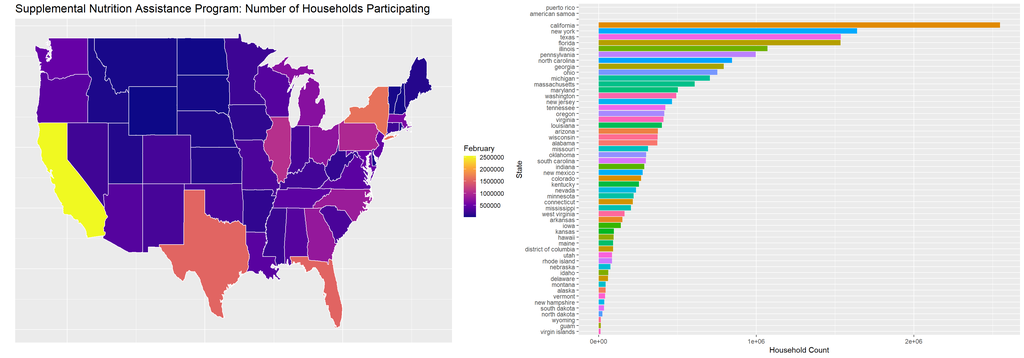

```r
plot_hh1 <- ggplot(snap_hh_map, aes(long, lat, group = group)) +
  geom_polygon(aes(fill = February), color = "white") +
  scale_fill_viridis_c(option = "C") +
  labs(x = "", y = "", title = "Supplemental Nutrition Assistance Program: Number of Households Participating") +
  theme(axis.text.x=element_blank(),
        axis.ticks.x=element_blank(),
        axis.text.y=element_blank(),
        axis.ticks.y=element_blank(),
        plot.title = element_text(size = 16))

plot_hh2 <- ggplot(snap_hh, aes(x = reorder(State, February), y = February, fill = State)) +
  geom_bar(stat = "identity") +
  labs(x = "State", y = "Household Count") +
  coord_flip() +
  theme(legend.position = "none")

grid.arrange(plot_hh1, plot_hh2, ncol=2)
```

The charts below display a similar dataset but of individuals instead of households. If we compare the Household map above to the Persons map below we see that the colors are very similar for most states. California is still the brightest with yellow, Florida and New York are a similar shade of orange, but Texas is a lighter shade. The barchart confirms that the number of individuals in Texas exceeds the number of individuals in New York and Florida remains the fourth highest.

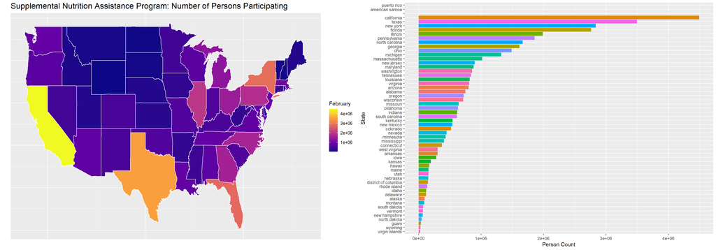

```r
plot_person1 <- ggplot(snap_person_map, aes(long, lat, group = group)) +
  geom_polygon(aes(fill = February), color = "white") +
  scale_fill_viridis_c(option = "C") +
  labs(x = "", y = "", title = "Supplemental Nutrition Assistance Program: Number of Persons Participating") +
  theme(axis.text.x=element_blank(),
        axis.ticks.x=element_blank(),
        axis.text.y=element_blank(),
        axis.ticks.y=element_blank(),
        plot.title = element_text(size = 16))

plot_person2 <- ggplot(snap_person, aes(x = reorder(State, February), y = February, fill = State)) +
  geom_bar(stat = "identity") +
  labs(x = "State", y = "Person Count") +
  coord_flip() +
  theme(legend.position = "none")

grid.arrange(plot_person1, plot_person2, ncol=2)
```

The shinyapp can also be accessed here: https://ltcancel.shinyapps.io/Final_Project/

```r
ui <- fluidPage(

  headerPanel("Food Sufficiency for Households: March 30-April 11"),

  sidebarPanel(
   selectInput('cause','Survey Question', unique(transformed_df$Question))
  ),

  fluidRow(
    column(10,plotOutput("plot1"))
    #column(6,tableOutput("table1"))
  )


  #fluidRow(
   # mainPanel(plotOutput("plot1", width = "100%"), tableOutput("table1"))
  #)




)
server <- function(input,output){

  output$plot1 <- renderPlot({

  filterdf <- transformed_df %>%
    filter(Question == input$cause)

  ggplot(filterdf, aes(fill = response, x = State, y = count)) +
    geom_bar(position = "stack", stat = "identity") +
    facet_wrap(~Characteristics, ncol = 1) +
    theme(legend.position = "top", axis.text = element_text(size = 14), axis.text.x = element_text(angle = 90), axis.title = element_text(size = 14), text = element_text(size = 14)) +
    labs(y = "Household Count", fill = "Survey Response")

  })

  output$table1 <- renderTable({
    filterdf <- transformed_df %>%
      filter(Question == input$cause)

    filterdf %>%
      na.omit() %>%
      group_by(State, response) %>%
      summarise(count = sum(count)) %>%
      spread(State, count)

  })

}

shinyApp(ui, server)
```

Shiny applications not supported in static R Markdown documents

# Resources

1. https://www.ers.usda.gov/topics/food-nutrition-assistance/food-security-in-the-u-s/definitions-of-food-security/
2. Number of persons and households participating in Supplemental Nutrition Assistance program (SNAP) as of May 3, 2022 https://www.fns.usda.gov/pd/supplemental-nutrition-assistance-program-snap
3. Week 44 Household Pulse Survey: March 30-April 11 https://www.census.gov/data/tables/2022/demo/hhp/hhp44.html